# Application of the GOF procedures for compound distribution on real insurance data set

Pierre-O Goffard

The inference and goodness-of-fit techniques developped in the FTCD package

are illustrated on an actuarial data set `itamtpltcost` accessible from the package `CASdatasets`.

| Date | UltimateCost |
| --- | --- |
| 08/01/1997 | 726986.95 |
| 02/03/1997 | 1222682.37 |
| 18/03/1997 | 428543.10 |
| 07/04/1997 | 258786.06 |
| 11/04/1997 | 637117.61 |
| 03/06/1997 | 1769925.16 |
| 15/06/1997 | 702034.03 |
| 23/06/1997 | 1082528.66 |
| 19/07/1997 | 1005364.03 |
| 22/07/1997 | 780910.04 |

[output cut: 447 more lines]

The data is available at the individual claim level, we can therefore process the data to get the aggregated version of it based on the date information. The original data is analysed so as to determine what might be a good distribution for the claim sizes. The inference and GOF procedures are then applied to the aggregate data, we can then appreciate the consistency of the results with that of the first analysis.

The quantile-quantile plot of the individual claims against the exponential distribution

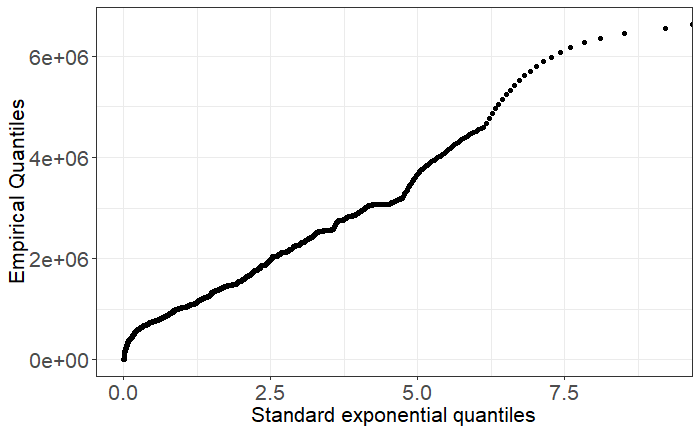

exhibits a linear trend for the lower level quantiles, the fit does not look adequate in the right tail of the data.

The quantile-quantile plot of the log losses against the exponential distribution shows a linear trend for the upper level quantiles

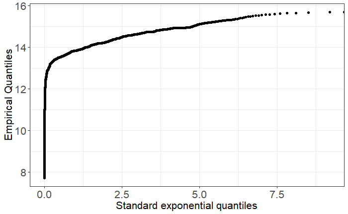

which means that a splicing model combining a light tailed distribution for the belly and a heavier tailed distribution for the right tail of the data might be a good idea.

This also implies a probable rejection of the compound models to be tested. The analysis is then conducted over the whole data set and on a subset made of the smaller claims. The claims that are lower than a threshold are considered to be small. The cut-off point is the upper order statistic that minimizes the asymptotic mean squared error of the Hill estimator. The mean excess plot and the Hill plot of the data are given below

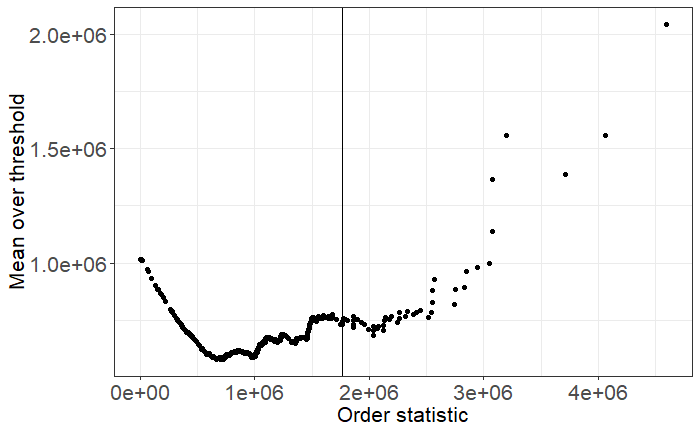

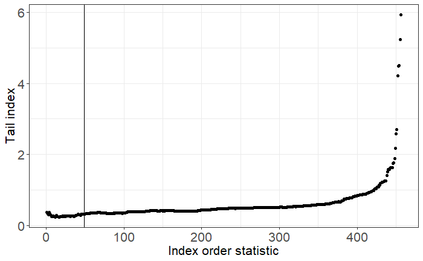

| Statitistics | overall | small_claims |
| --- | --- | --- |
| No of observations | 4.570000e+02 | 4.080000e+02 |
| E(U) | 1.015352e+06 | 8.372558e+05 |
| St.Dev(U) | 6.807420e+05 | 3.716465e+05 |
| Skewness(U) | 2.553692e+00 | 2.215236e-01 |
| Kurtosis(U) | 1.265475e+01 | -3.513811e-01 |
| Minimum | 2.160730e+03 | 2.160730e+03 |
| Maximum | 6.639500e+06 | 1.764900e+06 |
| Q1 | 6.277185e+05 | 5.954644e+05 |
| median | 8.440109e+05 | 7.909923e+05 |
| Q3 | 1.224316e+06 | 1.066904e+06 |

We note the swift decrease of variance when considering the small claims solely. The quartiles are stable while the mean in the small claims subset decreases to get closer to the median. Table reports the method of moments estimators of the parameters of the exponential and gamma distribution.

We will first assess the adequacy of the claim sizes data to the claim sizes distribution under $H_0$ including

- exponential
- gamma
- inverse Gaussian

[output not shown]

| parameters | estimates | estimates_small |
| --- | --- | --- |
| scale.exp | 1.015352e+06 | 8.372558e+05 |
| shape.gamma | 2.229563e+00 | 5.087704e+00 |
| scale.gamma | 4.554042e+05 | 1.645645e+05 |
| mean.invgauss | 1.015352e+06 | 8.372558e+05 |
| dispersion.invgauss | 4.427056e-07 | 2.353346e-07 |

We plot the histogram of the data and superimpose the density functions of the exponential, gamma and inverse Gaussian distribution on top of it.

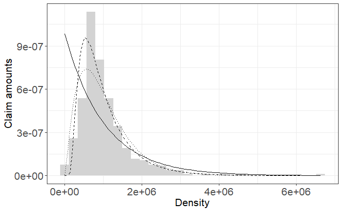

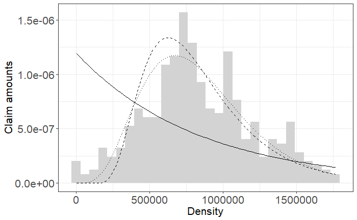

Now we assess the fit using goodneess of fit test and Akaike criteria on all the claims

| model | AIC | ks | ks_critical | cvm | cvm_critical |
| --- | --- | --- | --- | --- | --- |
| exponential | 13557.30 | 0.23961425 | 0.05283805 | 7.7931610 | 0.2091791 |
| gamma | 13403.02 | 0.09598139 | 0.04708473 | 1.0640569 | 0.1705399 |
| invgauss | 15498.63 | 0.07952371 | 0.04470183 | 0.5761735 | 0.2265545 |

and then on the small claims

| model | AIC | ks | ks_critical | cvm | cvm_critical |
| --- | --- | --- | --- | --- | --- |
| exponential | 11946.51 | 0.28185693 | 0.02712051 | 10.9709118 | 0.04908067 |
| gamma | 11765.60 | 0.04631331 | 0.03381544 | 0.2422084 | 0.09498050 |
| invgauss | 13859.68 | 0.06884298 | 0.04396959 | 0.6181199 | 0.15838364 |

The conclusion is that none of the models for the claim sizes lead to a good fit. We therefore expect the same conclusion when studying the aggregated data with our GOF techniques. Hereafter the data is processed so as to output the monthly aggregated data.

|  | mm_yy | claim_frequency | total_claim_size....total_claim_size |
| --- | --- | --- | --- |
| 1 | 01/1997 | 1 | 726986.9 |
| 2 | 02/1997 | 0 | 0.0 |
| 3 | 03/1997 | 2 | 1651225.5 |
| 4 | 04/1997 | 2 | 895903.7 |
| 5 | 05/1997 | 0 | 0.0 |

Now we turn to the study of the claim frequency distribution. We fit and assess the adequacy of the Poisson and geometric distribution to the claim count data.

[output not shown]

| model | estimated.parameters | Chisq | AIC |
| --- | --- | --- | --- |
| Poisson | 2.3802083 | 15.16650 | 752.7852 |
| geometric | 0.2958398 | 45.42213 | 790.2728 |
| Poisson | 1.9322917 | 17.13667 | 705.4827 |
| geometric | 0.3410302 | 32.66899 | 724.5727 |

The aggregated claim sizes data is fit using 6 different models including

- Poisson-exponential
- Poisson-gamma
- Poisson-inverse Gaussian
- Geometric-exponential
- Geometric-gamma
- Geometric-inverse Gaussian

| model | parameters | parameter_small |
| --- | --- | --- |
| Poisson-exponential | 1.856298e+00 | 1.519826e+00 |
| Poisson-exponential | 1.301919e+06 | 1.045750e+06 |
| Poisson-gamma | 1.856298e+00 | 1.519826e+00 |
| Poisson-gamma | 1.894618e+00 | 5.032327e+00 |
| Poisson-gamma | 6.871672e+05 | 2.078064e+05 |
| Poisson-invgauss | 1.856298e+00 | 1.519826e+00 |
| Poisson-invgauss | 1.301919e+06 | 1.045750e+06 |
| Poisson-invgauss | 4.054100e-07 | 1.900218e-07 |
| geometric-exponential | 1.562500e-01 | 2.187500e-01 |
| geometric-exponential | 4.475462e+05 | 4.450201e+05 |

The method of moment results in negative values of the parameter within the geometric-gamma and geometric-inverse Gaussian that are therefore discarded in the remainder of this study. We now apply our goodness-of-fit procedure staring with distribution based ones on all the claims

| model | KS | KS_critical | CvM | CvM_critical |
| --- | --- | --- | --- | --- |
| geometric-exp | 0.12996372 | 0.06955158 | 0.0052743634 | 0.0011147713 |
| poisson-exp | 0.09879537 | 0.06965393 | 0.0021290519 | 0.0010834653 |
| poisson-gamma | 0.04316388 | 0.05583971 | 0.0002655563 | 0.0008671906 |
| Poisson-inverse Gaussian | 0.03155067 | 0.05711873 | 0.0002225160 | 0.0006606096 |

then on the small claims

| model | KS | KS_critical | CvM | CvM_critical |
| --- | --- | --- | --- | --- |
| geometric-exp | 0.16887585 | 0.07720517 | 0.0092914962 | 0.0011768121 |
| poisson-exp | 0.14503598 | 0.06699845 | 0.0059862539 | 0.0009949389 |
| poisson-gamma | 0.03167797 | 0.06889915 | 0.0002011053 | 0.0013092854 |
| Poisson-inverse Gaussian | 0.03088687 | 0.06653922 | 0.0002092367 | 0.0009557274 |

We turn to the Laplace transform based techniques using the $\text{SE}_n(t)$ distance on all the claims

| model | beta_3 | beta_3_critical | beta_2 | beta_2_critical |
| --- | --- | --- | --- | --- |
| geometric-exp | 21.33016464 | 24.0932672 | 21.16076722 | 23.8657091 |
| poisson-exp | 3.61513907 | 2.4738142 | 3.20955139 | 1.0855763 |
| poisson-gamma | 0.04629677 | 0.4039991 | 0.04504389 | 0.3761409 |
| Poisson-inverse Gaussian | 0.02529597 | 0.1700570 | 0.02271229 | 0.1347263 |

Finally the Laplace transform based techniques using the $\text{DE}_n(t)$ distance on all the claims

| model | beta_0.1 | beta_0.1_critical | beta_1 | beta_1_critical |
| --- | --- | --- | --- | --- |
| geometric-exp | 19.67193 | 7.673904 | 1.005477256 | 0.1446596 |
| poisson-exp | 46.05852 | 22.162883 | 2.902153645 | 0.7881926 |
| poisson-gamma | 14.27362 | 31748.608812 | 0.144622793 | 2.3057944 |
| Poisson-inverse Gaussian | 12418.73440 | 751.048620 | 0.008937273 | 0.1983262 |

and on the small claims

| model | beta_0.1 | beta_0.1_critical | beta_1 | beta_1_critical |
| --- | --- | --- | --- | --- |
| geometric-exp | 3.615442e+01 | 1.327217e+01 | 1.8702639 | 0.1941347 |
| poisson-exp | 8.936073e+01 | 1.892965e+01 | 5.4869297 | 0.6289366 |
| poisson-gamma | 4.047951e+04 | 4.868835e+07 | 52.6424813 | 9098.9254282 |
| Poisson-inverse Gaussian | 1.721529e+10 | 1.127075e+08 | 0.0333928 | 0.7930569 |